# Base Model

## 3.2 Build Base Model

Although the knots can be set with percentiles or with the degree of freedom, we manually set the knots because we want the knots fixed when we run EnWAS to compare the impacts of the phenotypes fairly. We set age knots from 30 to 80 by 10s and boundary knots as (20, 90) because the age range is about 22 to 85. Increasing the number of knots may not hurt the model’s performance when the data size is relatively large, but it is better to set fewer knots in ranges with fewer data points. We need to set the knots when the data distribution is skewed carefully. As the BMI distribution is considerably skewed, data points larger than 45 are much less than those in the range of 15-45. Therefore, we set knots for BMI as 15 to 45 by 5s and 45 to 65 by 10s, and boundary knots as (10, 85). Note that boundary knots are required when the knots are manually set; otherwise, the models may raise errors when the knots are out of the data range.

```r
lm_str <- 'DIASTOLIC ~ RIDAGEYR*RIAGENDR + BMXBMI + RIDRETH1+nDEDUC+years'
lm_base <- lm(formula = as.formula(lm_str),base_df)

ns_str <-
  'DIASTOLIC ~ ns(RIDAGEYR, knots = seq(30, 80, by = 10), Boundary.knots=c(20,90)) * RIAGENDR + ns(BMXBMI,knots = c(seq(15, 45, by = 5),seq(45,65,by=10)),Boundary.knots=c(10,85)) + RIDRETH1+nDEDUC+years'
ns_base <- lm(formula = as.formula(ns_str), base_df)
```

## 4. QA/QC for Base Model

We need to check the base model and ensure it runs correctly before performing EnWAS. However, the classical methods such as Q-Q plots, residual plots, and goodness of fit (GoF) tests are generally ill-suited. For example, we can plot residuals against fitted values with smoothed scatter plot, as follows. We do not find any noticeable trends for none of the models; even the spline outperforms the linear model.

## 4.1 Residual vs. Fitted Value

We can check the residuals against the fitted value with a smooth scatter plot. And we find that there are no apparent trends for both models, even though the spline model has fewer mean square errors.

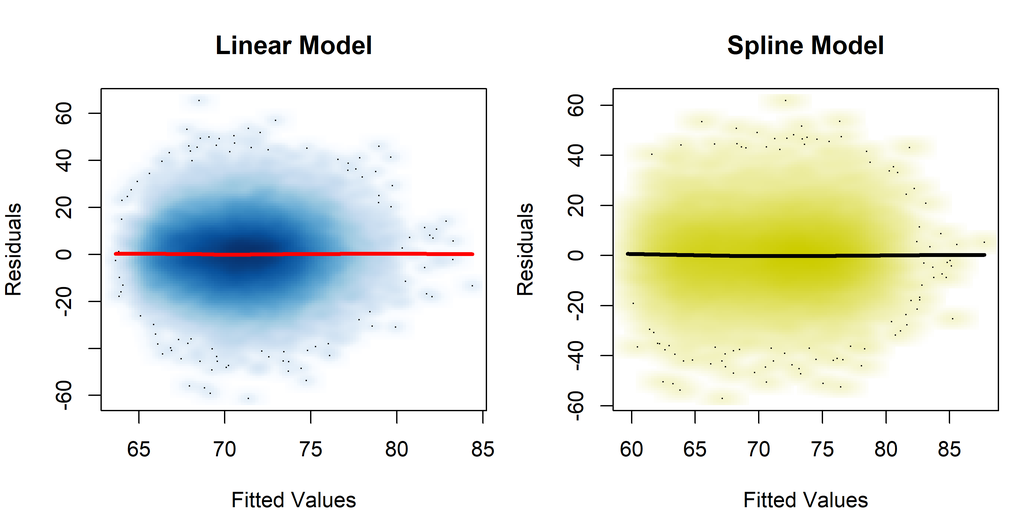

```r
# par(mfrow = c(1, 2))
layout(matrix(c(1,2), ncol=2, byrow=TRUE))
par(mar=c(4.0,4.0,3.5,1))
smoothScatter(lm_base$fitted.values,lm_base$residuals,xlab="Fitted Values",ylab ="Residuals",main = "Linear Model")
lines(lowess(lm_base$fitted.values,lm_base$residuals),lwd=3,col="red")
smoothScatter(ns_base$fitted.values,ns_base$residuals,
              colramp = colorRampPalette(c("white", "yellow3")),
              xlab="Fitted Values",ylab ="Residuals",main = "Spline Model")
lines(lowess(ns_base$fitted.values,ns_base$residuals),lwd=3,col="black")
```

### 4.2 Residuals vs. Terms

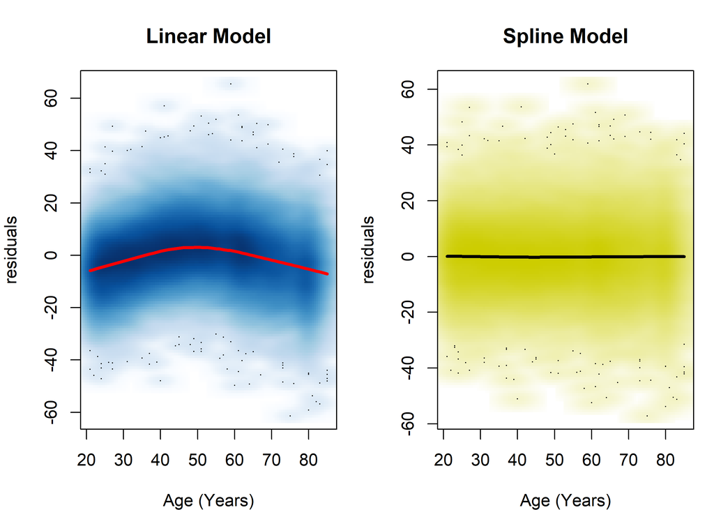

```r
# layout(matrix(c(1,2,3,4), ncol=2, byrow=TRUE))
# par(mar=c(4.0,4.0,2.5,2))



layout(matrix(c(1,2), ncol=2, byrow=TRUE))
par(mar=c(4.0,4.0,3.5,1))
smoothScatter(base_df$RIDAGEYR,lm_base$residuals,xlab="Age (Years)",ylab ="residuals",main = "Linear Model")
lines(lowess(base_df$RIDAGEYR,lm_base$residuals),lwd=3,col="red")
smoothScatter(base_df$RIDAGEYR,ns_base$residuals,xlab="Age (Years)",
              colramp = colorRampPalette(c("white", "yellow3")),
              ylab ="residuals",main = "Spline Model")
lines(lowess(base_df$RIDAGEYR,ns_base$residuals),lwd=3,col="black")
```

### 4.2 Binned Plots

We can further check the base models with binned plots, which can be helpful when the data set is large. The binned plot is a way that “zoom in” to look at the treends.

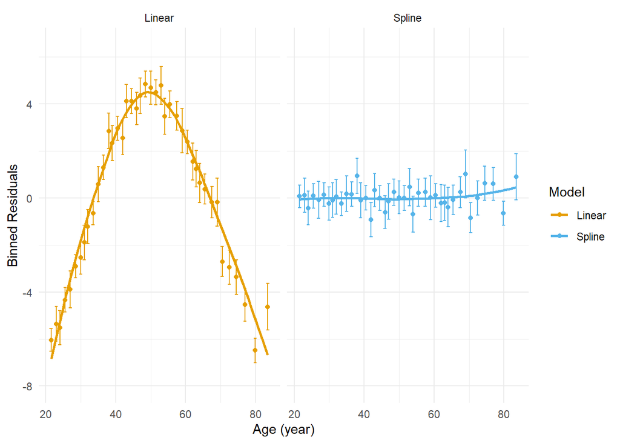

```r
df_age_res <- list("Linear"=make_bins(x=base_df$RIDAGEYR,y=lm_base$residual,nbin=1000),
                "Spline"=make_bins(x=base_df$RIDAGEYR,y=ns_base$residuals,nbin=1000)
                )
age_res <- plot_bins2(df_age_res,xlab="Age (year)",ylab="Binned Residuals") + ylim(-8,6.5)
age_res
```

```r
# Residuals vs. Fitted Values
pred_df <- data.frame("Age"=base_df$RIDAGEYR,
                      "Gender"=base_df$RIAGENDR,
                      "BMI"=base_df$BMXBMI,
                      "DIASTOLIC" = base_df$DIASTOLIC,
                      "Linear"=lm_base$fitted.values,
                      "Spline"=ns_base$fitted.values)



mpred_df <- reshape::melt(pred_df, id=c("DIASTOLIC","Age","Gender",'BMI'))

base_raw_g <- ggplot(mpred_df,
         aes(
           x = Age,
           y = DIASTOLIC
         )) +
  geom_point(data = ~ group_by(.x, Age, Gender,BMI) |> sample_frac(0.2),
             alpha = 0.2, shape=1) +
  geom_smooth(aes(x = Age,y=value,colour=variable),size=1.5,
              method='lm',formula=y ~ splines::ns(x,df=7)
              )+
  xlab("Age (year)")+ylab("Diastolic (mmHg)")+ facet_grid(cols = vars(variable))+
   scale_colour_manual(name="Model", values=c("#E69F00", "#56B4E9"))+
  theme_minimal()



pred_df <- data.frame("Age"=base_df$RIDAGEYR, "Gender"=base_df$RIAGENDR, "BMI"=base_df$BMXBMI,"DIASTOLIC" = base_df$DIASTOLIC,"Linear"=lm_base$residuals,"Spline"=ns_base$residuals)



mpred_df <- reshape::melt(pred_df, id=c("DIASTOLIC","Age","Gender",'BMI'))
res_g <- ggplot(
    mpred_df, aes(x = Age, y = value)) +
    stat_density2d(aes(fill = ..density..^0.25),
                   geom = "tile", contour = FALSE, n = 200) +
  geom_smooth(aes(x = Age,y=value,colour=variable),
              size=1.5,method='lm',formula=y ~ splines::ns(x,df=7))+
  facet_grid(cols = vars(variable))+scale_colour_manual(name="Model", values=c("#E69F00", "#56B4E9"))+
    viridis::scale_fill_viridis(guide="none",option = "A",alpha = 0.6) +
  ylab("Residuals")+ xlab("Age(year)")+
  theme_minimal()



tmp_df <- data.frame(Fitted_Value = c(lm_base$fitted.values,ns_base$fitted.values),
                     Residuals = c(lm_base$residuals,ns_base$residuals),
                     model = c(rep("Linear",nrow(base_df)),rep("Spline",nrow(base_df)))
                     )
fitt_g <- ggplot(tmp_df, aes(x = Fitted_Value, y = Residuals)) +
    stat_density2d(aes(fill = ..density..^0.25),
                   geom = "tile", contour = FALSE, n = 200) +
  geom_smooth(aes(x = Fitted_Value, y = Residuals,colour=model),
              size=1.5,method='lm',formula=y ~ splines::ns(x,df=7))+
  facet_grid(cols = vars(model))+
  scale_colour_manual(name="Model", values=c("#E69F00", "#56B4E9"))+
  xlab("Fitted Values")+
    scale_fill_viridis_c(alpha = 0.6,guide = "none") + theme_minimal()
```

- **a)** The yellow and blue lines are generated by smooth prediction from linear and spline models. The dots are randomly sampled in 20% of the data points.
- **b)** Smooth scatter plots for residuals with respect to fitted values, and there is no strong pattern in both cases even though the spline has less mean square error than the linear model.
- **c)** Smooth scatter plots for residuals with respect to age variable, and the linear model has a parabola-like pattern, whereas no obvious pattern for the spline model.
- **d)** Binned plots for residuals with respect to age variable to look at the trends of residuals against age.

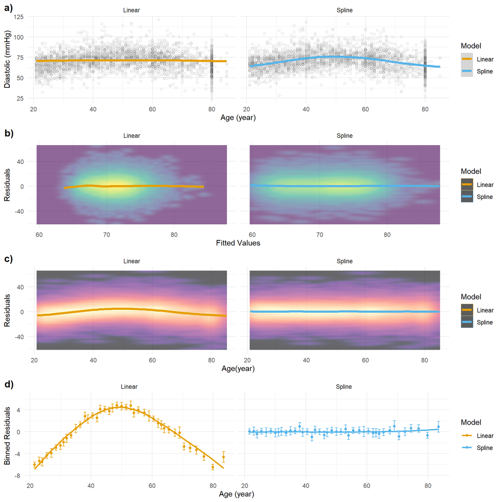

```r
ggpubr::ggarrange(base_raw_g,fitt_g,res_g,age_res,nrow = 4,ncol = 1,labels = c('a)','b)','c)','d)'))
```

### 4.3 Cross Validation

Cross-Validation to Linear vs Spline

```r
# model_list <- c(lm_str,ns_str)
# names(model_list) <- c("linear","spline")
# mse_mtx <- cv_base_m(model_list,label="DIASTOLIC",group_col="years",df=base_df)
# # knitr::kable(mse_mtx)
# mse_df <- as.data.frame(reshape2::melt(mse_mtx))
# colnames(mse_df) <- c('years','model','MSE')
# len_year <- length(levels(mse_df$years))
```

```r
# mse_df |> ggplot(aes(x=as.numeric(years),y=MSE,color=model)) +
#   geom_point(size=5)+ geom_line(linetype = "dashed")+
#   scale_x_continuous(breaks=seq(1,len_year,1),labels=levels(mse_df$years),
#                      guide = guide_axis(angle = 45))+ xlab("Years")+
#   theme_minimal()
```

## 4.3 ANOVA LRT (Likelihood Ratio Test)

```r
print_anova(anova(lm_base,ns_base,test="LRT"))
```

Analysis of Variance Table  
Model 1: DIASTOLIC ~ RIDAGEYR * RIAGENDR + BMXBMI + RIDRETH1 + nDEDUC +  
years  
Model 2: DIASTOLIC ~ ns(RIDAGEYR, knots = seq(30, 80, by = 10), Boundary.knots = c(20,  
90)) * RIAGENDR + ns(BMXBMI, knots = c(seq(15, 45, by = 5),  
seq(45, 65, by = 10)), Boundary.knots = c(10, 85)) + RIDRETH1 +  
nDEDUC + years

| Res.Df | RSS | Df | Sum of Sq | Pr(>Chi) |
| --- | --- | --- | --- | --- |
| 42557 | 5490094 |  |  |  |
| 42535 | 4900225 | 22 | 589868.921 | < 0.001 |

## 4.4 Vuong Tests for Model Comparison

We can consider the linear models as a sub model of the spline model, and we can run the nested version of Vuong Test.

```r
library(nonnest2)
vuongtest(lm_base,ns_base,nested = TRUE)
```

Variance test  
H0: Model 1 and Model 2 are indistinguishable  
H1: Model 1 and Model 2 are distinguishable  
w2 = 0.000, p = 1

Robust likelihood ratio test of distinguishable models  
H0: Model 2 fits as well as Model 1  
H1: Model 1 fits better than Model 2  
LR = 3213.299, p = 6.32e-09